# Exploring the Effectiveness of Machine Learning and Deep Learning Algorithms in Credit Card Fraud Detection: A Comparative Study

## Deep Learning

The research project will analyse and compare the performance of machine learning algorithms that are commonly used for credit card fraud detection.

The dataset being used is obtained from Kaggle- Credit Card Fraud Detection. The dataset consists of data from European cardholders from September 2013, with a total of 284,807 transactions. Out of the 284,807 transactions, 492 are fraudulent therefore, it is an imbalanced dataset.

The structure of the Jupyter Notebook is as follows:

- Part 1: Data Exploratory
- Part 2: Machine Learning and Deep Learning Algorithms

Part 1: Data Exploratory will consist of exploring the data and drop any features that are not useful for the analysis. The correlation between the features and the target variable will be determined and the features with a low correlation to the target variable are dropped.

Part 2: Machine Learning and Deep Learning Algorithms will consist of analysing the algorithms. Oversampling, undersampling and a combination of both will be used on the dataset.

## Part 1: Data Exploratory

### Importing the necessary libraries

```python
import pandas as pd
import numpy as np
import matplotlib.pyplot as plt
import seaborn as sns

import warnings
warnings.filterwarnings('ignore')
```

### Reading the data

Getting the data of the dataset.

```python
# Reading the 'creditcard.csv' file and storing it in a dataset
df = pd.read_csv('creditcard.csv')

# Displaying the first 5 rows to help understand what the dataset consists of
df.head()
```

|  | Time | V1 | V2 | V3 | V4 | V5 | V6 | V7 | V8 | V9 | ... | V21 | V22 | V23 | V24 | V25 | V26 | V27 | V28 | Amount | Class |
| --- | --- | --- | --- | --- | --- | --- | --- | --- | --- | --- | --- | --- | --- | --- | --- | --- | --- | --- | --- | --- | --- |
| 0 | 0.0 | -1.359807 | -0.072781 | 2.536347 | 1.378155 | -0.338321 | 0.462388 | 0.239599 | 0.098698 | 0.363787 | ... | -0.018307 | 0.277838 | -0.110474 | 0.066928 | 0.128539 | -0.189115 | 0.133558 | -0.021053 | 149.62 | 0 |
| 1 | 0.0 | 1.191857 | 0.266151 | 0.166480 | 0.448154 | 0.060018 | -0.082361 | -0.078803 | 0.085102 | -0.255425 | ... | -0.225775 | -0.638672 | 0.101288 | -0.339846 | 0.167170 | 0.125895 | -0.008983 | 0.014724 | 2.69 | 0 |
| 2 | 1.0 | -1.358354 | -1.340163 | 1.773209 | 0.379780 | -0.503198 | 1.800499 | 0.791461 | 0.247676 | -1.514654 | ... | 0.247998 | 0.771679 | 0.909412 | -0.689281 | -0.327642 | -0.139097 | -0.055353 | -0.059752 | 378.66 | 0 |
| 3 | 1.0 | -0.966272 | -0.185226 | 1.792993 | -0.863291 | -0.010309 | 1.247203 | 0.237609 | 0.377436 | -1.387024 | ... | -0.108300 | 0.005274 | -0.190321 | -1.175575 | 0.647376 | -0.221929 | 0.062723 | 0.061458 | 123.50 | 0 |
| 4 | 2.0 | -1.158233 | 0.877737 | 1.548718 | 0.403034 | -0.407193 | 0.095921 | 0.592941 | -0.270533 | 0.817739 | ... | -0.009431 | 0.798278 | -0.137458 | 0.141267 | -0.206010 | 0.502292 | 0.219422 | 0.215153 | 69.99 | 0 |

5 rows × 31 columns

Getting the shape of the dataset.

```python
# Displaying the dimensions of the dataset
df.shape
```

```
(284807, 31)
```

### Getting the data types of each variable

```python
# Displaying the information about the dataset
df.info()
```

```
<class 'pandas.core.frame.DataFrame'>
RangeIndex: 284807 entries, 0 to 284806
Data columns (total 31 columns):
 #   Column  Non-Null Count   Dtype
---  ------  --------------   -----
 0   Time    284807 non-null  float64
 1   V1      284807 non-null  float64
 2   V2      284807 non-null  float64
 3   V3      284807 non-null  float64
 4   V4      284807 non-null  float64
 5   V5      284807 non-null  float64
 6   V6      284807 non-null  float64
 7   V7      284807 non-null  float64
 8   V8      284807 non-null  float64
 9   V9      284807 non-null  float64
```

[output cut: 23 more lines]

The above shows that there are no null values in the dataset. The data types of the features are either float64 or int64.

Time, Amount and Class are the only features that can be seen, that is they are the only features that we know what they represent exactly. Principal Component Analysis (PCA) was used to reduce the dimensionality of the features, V1 to V28.

### Unique Values

The unique values of every column will be determined. This will help determine if there are any duoplicate values.

```python
# Unique values of each column
df.nunique()
```

```
Time      124592
V1        275663
V2        275663
V3        275663
V4        275663
V5        275663
V6        275663
V7        275663
V8        275663
V9        275663
V10       275663
V11       275663
V12       275663
V13       275663
V14       275663
V15       275663
V16       275663
V17       275663
V18       275663
V19       275663
V20       275663
V21       275663
V22       275663
V23       275663
V24       275663
V25       275663
V26       275663
V27       275663
V28       275663
Amount     32767
Class          2
dtype: int64
```

The above shows that there are duplicate values. The next step is to see how many duplicate values the dataset has and then drop these values.

### Dropping the duplicate values

```python
# Counting the number of duplicate rows in the dataset
df.duplicated().sum()
```

```
1081
```

There are a total of 1081 duplicate values. These values will be dropped.

```python
# Removing the duplicate rows from the dataset
df.drop_duplicates(keep = 'first', inplace = True)
```

```python
# Making sure that there are no more duplicate rows
df.duplicated().sum()
```

```
0
```

This confirms that all the duplicate rows have been dropped.

### Splitting the data

Splitting the data into input features which will be put under features and the output feature which will be the target.

```python
# Separating the features and target variable
# Input features
features = df.iloc[:,:-1]
# Output feature - Class
target = df.iloc[:,-1]
```

```python
# Displaying the a few rows of the dataset containing the features variables
features
```

|  | Time | V1 | V2 | V3 | V4 | V5 | V6 | V7 | V8 | V9 | ... | V20 | V21 | V22 | V23 | V24 | V25 | V26 | V27 | V28 | Amount |
| --- | --- | --- | --- | --- | --- | --- | --- | --- | --- | --- | --- | --- | --- | --- | --- | --- | --- | --- | --- | --- | --- |
| 0 | 0.0 | -1.359807 | -0.072781 | 2.536347 | 1.378155 | -0.338321 | 0.462388 | 0.239599 | 0.098698 | 0.363787 | ... | 0.251412 | -0.018307 | 0.277838 | -0.110474 | 0.066928 | 0.128539 | -0.189115 | 0.133558 | -0.021053 | 149.62 |
| 1 | 0.0 | 1.191857 | 0.266151 | 0.166480 | 0.448154 | 0.060018 | -0.082361 | -0.078803 | 0.085102 | -0.255425 | ... | -0.069083 | -0.225775 | -0.638672 | 0.101288 | -0.339846 | 0.167170 | 0.125895 | -0.008983 | 0.014724 | 2.69 |
| 2 | 1.0 | -1.358354 | -1.340163 | 1.773209 | 0.379780 | -0.503198 | 1.800499 | 0.791461 | 0.247676 | -1.514654 | ... | 0.524980 | 0.247998 | 0.771679 | 0.909412 | -0.689281 | -0.327642 | -0.139097 | -0.055353 | -0.059752 | 378.66 |
| 3 | 1.0 | -0.966272 | -0.185226 | 1.792993 | -0.863291 | -0.010309 | 1.247203 | 0.237609 | 0.377436 | -1.387024 | ... | -0.208038 | -0.108300 | 0.005274 | -0.190321 | -1.175575 | 0.647376 | -0.221929 | 0.062723 | 0.061458 | 123.50 |
| 4 | 2.0 | -1.158233 | 0.877737 | 1.548718 | 0.403034 | -0.407193 | 0.095921 | 0.592941 | -0.270533 | 0.817739 | ... | 0.408542 | -0.009431 | 0.798278 | -0.137458 | 0.141267 | -0.206010 | 0.502292 | 0.219422 | 0.215153 | 69.99 |
| ... | ... | ... | ... | ... | ... | ... | ... | ... | ... | ... | ... | ... | ... | ... | ... | ... | ... | ... | ... | ... | ... |
| 284802 | 172786.0 | -11.881118 | 10.071785 | -9.834783 | -2.066656 | -5.364473 | -2.606837 | -4.918215 | 7.305334 | 1.914428 | ... | 1.475829 | 0.213454 | 0.111864 | 1.014480 | -0.509348 | 1.436807 | 0.250034 | 0.943651 | 0.823731 | 0.77 |
| 284803 | 172787.0 | -0.732789 | -0.055080 | 2.035030 | -0.738589 | 0.868229 | 1.058415 | 0.024330 | 0.294869 | 0.584800 | ... | 0.059616 | 0.214205 | 0.924384 | 0.012463 | -1.016226 | -0.606624 | -0.395255 | 0.068472 | -0.053527 | 24.79 |
| 284804 | 172788.0 | 1.919565 | -0.301254 | -3.249640 | -0.557828 | 2.630515 | 3.031260 | -0.296827 | 0.708417 | 0.432454 | ... | 0.001396 | 0.232045 | 0.578229 | -0.037501 | 0.640134 | 0.265745 | -0.087371 | 0.004455 | -0.026561 | 67.88 |
| 284805 | 172788.0 | -0.240440 | 0.530483 | 0.702510 | 0.689799 | -0.377961 | 0.623708 | -0.686180 | 0.679145 | 0.392087 | ... | 0.127434 | 0.265245 | 0.800049 | -0.163298 | 0.123205 | -0.569159 | 0.546668 | 0.108821 | 0.104533 | 10.00 |
| 284806 | 172792.0 | -0.533413 | -0.189733 | 0.703337 | -0.506271 | -0.012546 | -0.649617 | 1.577006 | -0.414650 | 0.486180 | ... | 0.382948 | 0.261057 | 0.643078 | 0.376777 | 0.008797 | -0.473649 | -0.818267 | -0.002415 | 0.013649 | 217.00 |

283726 rows × 30 columns

```python
# Displaying the a few rows of the dataset containing the target variable, Class
target
```

```
0         0
1         0
2         0
3         0
4         0
         ..
284802    0
284803    0
284804    0
284805    0
284806    0
Name: Class, Length: 283726, dtype: int64
```

0 = Not Fraudulent 1 = Fraudulent

```python
# Counting the number of times each unique value appears
target.value_counts()
```

```
0    283253
1       473
Name: Class, dtype: int64
```

The above shows that the dataset is highly imbalanced. There are more non-fraudulent transactions than fraudulent transactions.

### Plotting the target variable

Plotting the count of fraudulent and non-fraudulent transactions in the Class column.

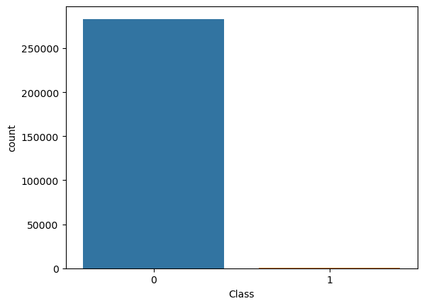

```python
# Count plot of the Class column
sns.countplot(data = df, x = 'Class')
```

### Correlation between features and target

```
<BarContainer object of 30 artists>
```

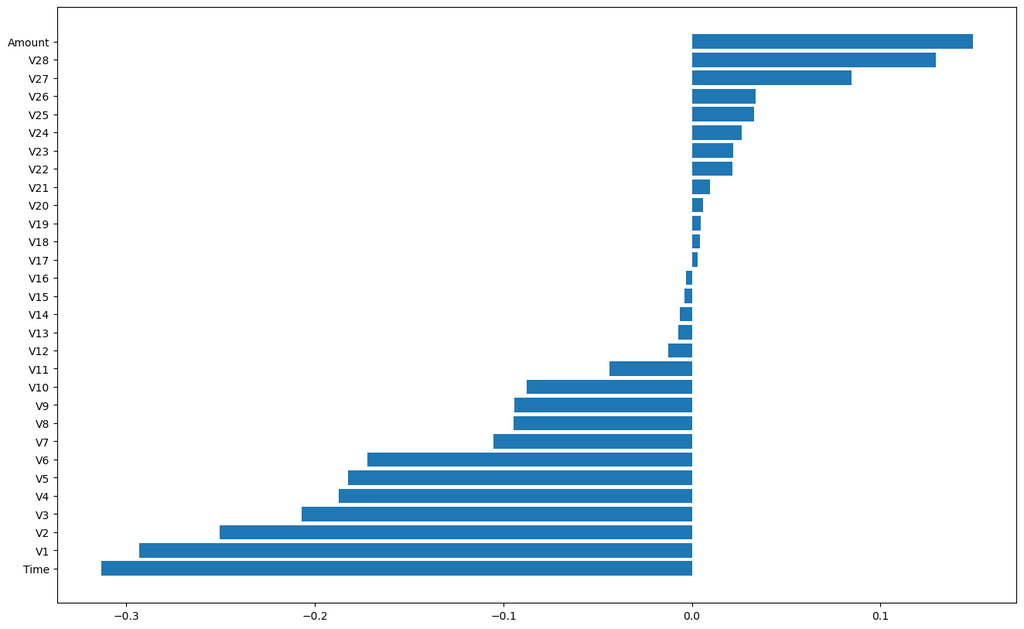

```python
# Getting the list of columns from the dataset, excluding Class
col = df.describe().transpose().index
col = col.tolist()
col.remove('Class')

# Initializing an empty list so the correlation of values between features and target are stored in the list
correlation = []

# Looping through each feature to calculate the correlation with 'Class'
for i in col:
    correlation.append(np.corrcoef(df[i], df['Class'])[0,1])

# Sorting the values in ascending order
correlation.sort()

# Creating a horizontal bar plot to plot the correlation for each feature
fig, ax = plt.subplots(figsize=(16,10))
ax.barh(col, correlation)
```

The above figure shows the correlation between the features and the output feature, Class. The features with a low correlation will be dropped.

### Dropping the features with low correlation

Dropping V14, V15, V16, V17, V18, V19 and V20 since they have a low correlation.

```python
df.drop(df[['V14', 'V15', 'V16', 'V17', 'V18', 'V19', 'V20']], axis = 1, inplace = True)
```

```python
# Printing the columns to make sure that the above columns were dropped
df.columns
```

```
Index(['Time', 'V1', 'V2', 'V3', 'V4', 'V5', 'V6', 'V7', 'V8', 'V9', 'V10',
       'V11', 'V12', 'V13', 'V21', 'V22', 'V23', 'V24', 'V25', 'V26', 'V27',
       'V28', 'Amount', 'Class'],
      dtype='object')
```

It shows that the features with a low correlation were dropped.

## Part 2: Machine Learning and Deep Learning Algorithms

### Importing the necessary libraries

```python
# Importing the necessary libraries to implement the deep learning algorithms
from tensorflow.keras.models import Sequential
from tensorflow.keras.layers import LSTM, Dense
import tensorflow as tf
```

```python
# Importing the accuracy
from sklearn.metrics import accuracy_score
```

Installing the imbalanced-learn package. This will be used to import the necessary packages.

```python
!pip install -U imbalanced-learn
```

```python
# Importing the oversampling, undersampling and a combination of both- SMOTE, Tomek Links, SMOTETomek respectively
from imblearn.over_sampling import SMOTE
from imblearn.under_sampling import TomekLinks
from imblearn.combine import SMOTETomek
```

### Splitting the dataset into train and test

```python
# Defining the input features and output feature
X = df.drop(['Class'], axis = 1) # Input features
Y = df['Class'] # Output feature
```

Scaling the features so that the input features are on a similar scale which makes the algorithms run faster and achieve a better performance.

```python
from sklearn.preprocessing import StandardScaler
# Scale the features
scaler = StandardScaler()
X = scaler.fit_transform(X)
```

```python
from sklearn.model_selection import train_test_split
# Split into train and test sets
x_train, x_test, y_train, y_test = train_test_split(X, Y, test_size=0.3, random_state=42)
```

### Oversampling

SMOTE stands for Synthetic Minority Over-Sampling Technique. SMOTE will be used as an oversampling technique.

#### Long Short-Term Memory Network

```python
# Applying SMOTE to balance the data in the training dataset
LSTM_smote = SMOTE(random_state=42)
x_train_smote, y_train_smote = LSTM_smote.fit_resample(x_train, y_train)

# Reshaping the input data to fit into LSTM model
x_train_reshaped = x_train_smote.reshape((x_train_smote.shape[0], 1, x_train_smote.shape[1]))
x_test_reshaped = x_test.reshape((x_test.shape[0], 1, x_test.shape[1]))

# Defining the algorithm's architecture
lstm = Sequential()
lstm.add(LSTM(64, activation='relu', input_shape=(1, x_train_smote.shape[1])))
lstm.add(Dense(32, activation='relu'))
lstm.add(Dense(16, activation='relu'))
lstm.add(Dense(1, activation='sigmoid'))

# Compiling the model
lstm.compile(optimizer='adam', loss='binary_crossentropy', metrics=['accuracy'])

# Training the model
history = lstm.fit(x_train_reshaped, y_train_smote, epochs=10, batch_size=32, validation_data=(x_test_reshaped, y_test))

# Making predictions on the test set
y_pred = lstm.predict(x_test_reshaped)
y_pred_classes = np.round(y_pred)

# Calculating the performance metrics
accuracy = accuracy_score(y_test, y_pred_classes)
error_rate = 1 - accuracy
```

```python
# calculating the average of each performance metric and multiplying by 100 to print it as a percentage
# printing the accuracy
print("Accuracy: {:.2f}%".format(np.mean(accuracy) * 100))
# printing the error rate
print("Error Rate: {:.2f}%".format(np.mean(error_rate) * 100))
```

```
Accuracy: 99.91%
Error Rate: 0.09%
```

#### Multi-Layer Perceptron

```python
# Applying SMOTE to balance the data in the training dataset
MLP_smote = SMOTE(random_state=42)
x_train_smote, y_train_smote = MLP_smote.fit_resample(x_train, y_train)

# Defining the algorithm's architecture
MLP = tf.keras.Sequential([
  tf.keras.layers.Dense(64, activation='relu', input_shape=(x_train.shape[1],)),
  tf.keras.layers.Dense(32, activation='relu'),
  tf.keras.layers.Dense(16, activation='relu'),
  tf.keras.layers.Dense(1, activation='sigmoid')
])

# Compiling the model
MLP.compile(optimizer='adam', loss='binary_crossentropy', metrics=['accuracy'])

# Training the model
history = MLP.fit(x_train_smote, y_train_smote, epochs=10, batch_size=32, validation_data=(x_test, y_test))

# Making predictions on the test set
y_pred = MLP.predict(x_test)
y_pred_classes = np.round(y_pred)

# Calculating the performance metrics
accuracy = accuracy_score(y_test, y_pred_classes)
error_rate = 1 - accuracy
```

```python
# calculating the average of each performance metric and multiplying by 100 to print it as a percentage
# printing the accuracy
print("Accuracy: {:.2f}%".format(np.mean(accuracy) * 100))
# printing the error rate
print("Error Rate: {:.2f}%".format(np.mean(error_rate) * 100))
```

```
Accuracy: 99.89%
Error Rate: 0.11%
```

#### Recurrent Neural Network

```python
# Applying SMOTE to deal with imbalanced classes
RNN_smote = SMOTE(random_state=42)
x_train_smote, y_train_smote = RNN_smote.fit_resample(x_train, y_train)

# Reshaping the input data to fit the RNN input shape
x_train_reshaped = np.reshape(x_train_smote, (x_train_smote.shape[0], 1, x_train_smote.shape[1]))
x_test_reshaped = np.reshape(x_test, (x_test.shape[0], 1, x_test.shape[1]))

# Defining the RNN architecture
rnn = tf.keras.Sequential([
    tf.keras.layers.LSTM(64, input_shape=(1, 23)),
    tf.keras.layers.Dense(1, activation="sigmoid")
])

# Compiling the model
rnn.compile(optimizer="adam", loss="binary_crossentropy", metrics=["accuracy"])

# Training the model
rnn.fit(x_train_reshaped, y_train_smote, epochs=10, batch_size=32)

# Making predictions on the test set
y_pred_probs = rnn.predict(x_test_reshaped)
y_pred_classes = np.argmax(y_pred_probs, axis=1)

# Calculate the performance metrics
accuracy = accuracy_score(y_test, y_pred_classes)
error_rate = 1 - accuracy
```

```python
# calculating the average of each performance metric and multiplying by 100 to print it as a percentage
# printing the accuracy
print("Accuracy: {:.2f}%".format(np.mean(accuracy) * 100))
# printing the error rate
print("Error Rate: {:.2f}%".format(np.mean(error_rate) * 100))
```

```
Accuracy: 99.84%
Error Rate: 0.16%
```

### Undersampling

Tomek Links will be used as an undersampling technique.

#### Long Short-Term Memory Network

```python
# Applying Tomek Links to balance the data in the training dataset
LSTM_tomek = TomekLinks()
x_train_tl, y_train_tl = LSTM_tomek.fit_resample(x_train, y_train)

# Reshaping the input data to fit into LSTM model
x_train_reshaped = x_train_tl.reshape((x_train_tl.shape[0], 1, x_train_tl.shape[1]))
x_test_reshaped = x_test.reshape((x_test.shape[0], 1, x_test.shape[1]))

# Defining the algorithm's architecture
lstm = Sequential()
lstm.add(LSTM(64, activation='relu', input_shape=(1, x_train_tl.shape[1])))
lstm.add(Dense(32, activation='relu'))
lstm.add(Dense(16, activation='relu'))
lstm.add(Dense(1, activation='sigmoid'))

# Compiling the model
lstm.compile(optimizer='adam', loss='binary_crossentropy', metrics=['accuracy'])

# Training the model
history = lstm.fit(x_train_reshaped, y_train_tl, epochs=10, batch_size=32, validation_data=(x_test_reshaped, y_test))

# Making predictions on the test set
y_pred = lstm.predict(x_test_reshaped)
y_pred_classes = np.round(y_pred)

# Calculating the performance metrics
accuracy = accuracy_score(y_test, y_pred_classes)
error_rate = 1 - accuracy
```

```python
# calculating the average of each performance metric and multiplying by 100 to print it as a percentage
# printing the accuracy
print("Accuracy: {:.2f}%".format(np.mean(accuracy) * 100))
# printing the error rate
print("Error Rate: {:.2f}%".format(np.mean(error_rate) * 100))
```

```
Accuracy: 99.95%
Error Rate: 0.05%
```

#### Multi-Layer Perceptron

```python
# Applying Tomek Links to balance the data in the training dataset
MLP_tomek = TomekLinks()
x_train_tomek, y_train_tomek = MLP_tomek.fit_resample(x_train, y_train)

# Defining the algorithm's architecture
MLP = tf.keras.Sequential([
  tf.keras.layers.Dense(64, activation='relu', input_shape=(x_train.shape[1],)),
  tf.keras.layers.Dense(32, activation='relu'),
  tf.keras.layers.Dense(16, activation='relu'),
  tf.keras.layers.Dense(1, activation='sigmoid')
])

# Compiling the model
MLP.compile(optimizer='adam', loss='binary_crossentropy', metrics=['accuracy'])

# Training the model
history = MLP.fit(x_train_tomek, y_train_tomek, epochs=10, batch_size=32, validation_data=(x_test, y_test))

# Making predictions on the test set
y_pred = MLP.predict(x_test)
y_pred_classes = np.round(y_pred)

# Calculating the performance metrics
accuracy = accuracy_score(y_test, y_pred_classes)
error_rate = 1 - accuracy
```

```python
# calculating the average of each performance metric and multiplying by 100 to print it as a percentage
# printing the accuracy
print("Accuracy: {:.2f}%".format(np.mean(accuracy) * 100))
# printing the error rate
print("Error Rate: {:.2f}%".format(np.mean(error_rate) * 100))
```

```
Accuracy: 99.94%
Error Rate: 0.06%
```

#### Recurrent Neural Network

```python
# Applying Tomek Links to the training data
RNN_tomek = TomekLinks()
x_train_tomek, y_train_tomek = RNN_tomek.fit_resample(x_train, y_train)

# Reshaping the input data to fit the RNN input shape
x_train_reshaped = np.reshape(x_train_tomek, (x_train_tomek.shape[0], 1, x_train_tomek.shape[1]))
x_test_reshaped = np.reshape(x_test, (x_test.shape[0], 1, x_test.shape[1]))

# Defining the RNN architecture
rnn = tf.keras.Sequential([
    tf.keras.layers.LSTM(64, input_shape=(1, 23)),
    tf.keras.layers.Dense(1, activation="sigmoid")
])

# Compiling the model
rnn.compile(optimizer="adam", loss="binary_crossentropy", metrics=["accuracy"])

# Training the model
rnn.fit(x_train_reshaped, y_train_tomek, epochs=10, batch_size=32)

# Making predictions on the test set
y_pred_probs = rnn.predict(x_test_reshaped)
y_pred_classes = np.argmax(y_pred_probs, axis=1)

# Calculate the performance metrics
accuracy = accuracy_score(y_test, y_pred_classes)
error_rate = 1 - accuracy
```

```python
# calculating the average of each performance metric and multiplying by 100 to print it as a percentage
# printing the accuracy
print("Accuracy: {:.2f}%".format(np.mean(accuracy) * 100))
# printing the error rate
print("Error Rate: {:.2f}%".format(np.mean(error_rate) * 100))
```

```
Accuracy: 99.84%
Error Rate: 0.16%
```

### Combination of oversampling and undersampling

SMOTETomek is a hybrid technique that combines both SMOTE and Tomek Link. SMOTETomek will be used as an oversampling and undersampling technique.

#### Long Short-Term Memory Network

```python
# Applying SMOTETomek to balance the data in the training dataset
LSTM_smotetomek = SMOTETomek(random_state=42)
x_train_smt, y_train_smt = LSTM_smotetomek.fit_resample(x_train, y_train)

# Reshaping the input data to fit into LSTM model
x_train_reshaped = x_train_smt.reshape((x_train_smt.shape[0], 1, x_train_smt.shape[1]))
x_test_reshaped = x_test.reshape((x_test.shape[0], 1, x_test.shape[1]))

# Defining the algorithm's architecture
lstm = Sequential()
lstm.add(LSTM(64, activation='relu', input_shape=(1, x_train_smt.shape[1])))
lstm.add(Dense(32, activation='relu'))
lstm.add(Dense(16, activation='relu'))
lstm.add(Dense(1, activation='sigmoid'))

# Compiling the model
lstm.compile(optimizer='adam', loss='binary_crossentropy', metrics=['accuracy'])

# Training the model
history = lstm.fit(x_train_reshaped, y_train_smt, epochs=10, batch_size=32, validation_data=(x_test_reshaped, y_test))

# Making predictions on the test set
y_pred = lstm.predict(x_test_reshaped)
y_pred_classes = np.round(y_pred)

# Calculating the performance metrics
accuracy = accuracy_score(y_test, y_pred_classes)
error_rate = 1 - accuracy
```

```python
# calculating the average of each performance metric and multiplying by 100 to print it as a percentage
# printing the accuracy
print("Accuracy: {:.2f}%".format(np.mean(accuracy) * 100))
# printing the error rate
print("Error Rate: {:.2f}%".format(np.mean(error_rate) * 100))
```

```
Accuracy: 99.93%
Error Rate: 0.07%
```

#### Multi-Layer Perceptron

```python
# Applying SMOTETomek to balance the data in the training dataset
MLP_smotetomek = SMOTETomek(random_state=42)
x_train_smt, y_train_smt = MLP_smotetomek.fit_resample(x_train, y_train)

# Defining the algorithm's architecture
MLP = tf.keras.Sequential([
  tf.keras.layers.Dense(64, activation='relu', input_shape=(x_train.shape[1],)),
  tf.keras.layers.Dense(32, activation='relu'),
  tf.keras.layers.Dense(16, activation='relu'),
  tf.keras.layers.Dense(1, activation='sigmoid')
])

# Compiling the model
MLP.compile(optimizer='adam', loss='binary_crossentropy', metrics=['accuracy'])

# Training the model
history = MLP.fit(x_train_smt, y_train_smt, epochs=10, batch_size=32, validation_data=(x_test, y_test))

# Making predictions on the test set
y_pred = MLP.predict(x_test)
y_pred_classes = np.round(y_pred)

# Calculating the performance metrics
accuracy = accuracy_score(y_test, y_pred_classes)
error_rate = 1 - accuracy
```

```python
# calculating the average of each performance metric and multiplying by 100 to print it as a percentage
# printing the accuracy
print("Accuracy: {:.2f}%".format(np.mean(accuracy) * 100))
# printing the error rate
print("Error Rate: {:.2f}%".format(np.mean(error_rate) * 100))
```

```
Accuracy: 99.91%
Error Rate: 0.09%
```

#### Recurrent Neural Network

```python
# Applying SMOTETomek to deal with imbalanced classes
RNN_smotetomek = SMOTETomek(random_state=42)
x_train_smtk, y_train_smtk = RNN_smotetomek.fit_resample(x_train, y_train)

# Reshaping the input data to fit the RNN input shape
x_train_reshaped = np.reshape(x_train_smtk, (x_train_smtk.shape[0], 1, x_train_smtk.shape[1]))
x_test_reshaped = np.reshape(x_test, (x_test.shape[0], 1, x_test.shape[1]))

# Defining the RNN architecture
rnn = tf.keras.Sequential([
    tf.keras.layers.LSTM(64, input_shape=(1, 23)),
    tf.keras.layers.Dense(1, activation="sigmoid")
])

# Compiling the model
rnn.compile(optimizer="adam", loss="binary_crossentropy", metrics=["accuracy"])

# Training the model
rnn.fit(x_train_reshaped, y_train_smtk, epochs=10, batch_size=32)

# Making predictions on the test set
y_pred_probs = rnn.predict(x_test_reshaped)
y_pred_classes = np.argmax(y_pred_probs, axis=1)

# Calculate the performance metrics
accuracy = accuracy_score(y_test, y_pred_classes)
error_rate = 1 - accuracy
```

```python
# calculating the average of each performance metric and multiplying by 100 to print it as a percentage
# printing the accuracy
print("Accuracy: {:.2f}%".format(np.mean(accuracy) * 100))
# printing the error rate
print("Error Rate: {:.2f}%".format(np.mean(error_rate) * 100))
```

```
Accuracy: 99.84%
Error Rate: 0.16%
```